# Weather Analysis

## Created by Troy Engelhardt

**UPDATE:** Edits have been made to make this work 24-03-2018

**CAUTION:** When you run this notebook all the Bokeh plots I've made will open in new tabs; you can just exit these new tabs as they appear because they've also been output to this notebook (I couldn't figure out how to stop them all opening in new tabs). Also, along with all the .html file from the Bokeh plots, 12 .csv files containing all the weather data will be downloaded to the working directory.

### Importing everything

```python
import os
import numpy as np
import pandas as pd
import matplotlib.pyplot as plt
import matplotlib.lines as mlines
%matplotlib inline
from bokeh.plotting import figure, output_file, show, output_notebook
from bokeh.models import formatters
```

### Grabbing the data

This chunk is essentially a script which grabs each .csv file (Perth weather data from May 2016 - April 2017) from the Bureau of Meteorology's website.

```python
# WARNING: running this will download 12 files to working directory

# setup an array of dates I need
months = ['201605','201606','201607','201608','201609','201610',
              '201611','201612','201701','201702','201703','201704']

# iterating through a grep command
# for item in months:
#     os.system("wget http://www.bom.gov.au/climate/dwo/" + item +
#               "/text/IDCJDW6111." + item + ".csv")
```

### Cleaning the data

```python
# renames the files to make them look nicer
# for filename in os.listdir('.'):
#     if filename.startswith('IDCJDW6111.'):
#         os.rename(filename, filename[11:])
```

```python
weather = dict()

# UPDATE: added 'parse_dates=' so fancy plotting would work
for item in months:
    weather[item] = pd.read_csv(item + ".csv", header = 0, parse_dates=['Date'],
                                usecols=[1,2,3,4,5,6,7,8,9,10,11,12,13,14,15,16,17,18,19,20,21])
```

```python
# weather = dict()

# # UPDATE: added 'parse_dates=' so fancy plotting would work
# for item in months:
#     weather[item] = pd.read_csv(item + ".csv", header = 0,
#                                 usecols=[1,2,3,4,5,6,7,8,9,10,11,12,13,14,15,16,17,18,19,20,21])

# for i in months:
#     pd.to_datetime(weather[i]['Date'], format = '%d/%m/%Y')
```

Just making sure everything *somewhat* works.

```python
weather['201701'].describe()
```

|  | Minimum temperature (°C) | Maximum temperature (°C) | Rainfall (mm) | Evaporation (mm) | Sunshine (hours) | Speed of maximum wind gust (km/h) | 9am Temperature (°C) | 9am relative humidity (%) | 9am cloud amount (oktas) | 9am wind speed (km/h) | 9am MSL pressure (hPa) | 3pm Temperature (°C) | 3pm relative humidity (%) | 3pm cloud amount (oktas) | 3pm wind speed (km/h) | 3pm MSL pressure (hPa) |
| --- | --- | --- | --- | --- | --- | --- | --- | --- | --- | --- | --- | --- | --- | --- | --- | --- |
| count | 31.000000 | 31.000000 | 31.000000 | 31.000000 | 31.000000 | 31.000000 | 31.000000 | 31.000000 | 31.000000 | 31.000000 | 31.000000 | 31.000000 | 31.000000 | 31.000000 | 31.000000 | 31.000000 |
| mean | 16.793548 | 30.993548 | 1.464516 | 10.200000 | 11.254839 | 38.225806 | 24.129032 | 48.451613 | 1.967742 | 11.806452 | 1012.006452 | 28.841935 | 40.677419 | 1.580645 | 16.903226 | 1009.500000 |
| std | 2.713907 | 6.335873 | 5.866149 | 2.838309 | 3.934195 | 5.542019 | 4.489929 | 18.433373 | 2.834124 | 4.061357 | 3.164800 | 6.244452 | 20.047256 | 2.579072 | 4.935280 | 2.984962 |
| min | 11.500000 | 20.300000 | 0.000000 | 1.400000 | 0.000000 | 28.000000 | 17.000000 | 17.000000 | 0.000000 | 6.000000 | 1006.100000 | 18.400000 | 9.000000 | 0.000000 | 2.000000 | 1003.600000 |
| 25% | 15.100000 | 24.950000 | 0.000000 | 9.100000 | 11.650000 | 35.000000 | 21.050000 | 38.500000 | 0.000000 | 9.000000 | 1010.000000 | 23.400000 | 29.500000 | 0.000000 | 15.000000 | 1007.700000 |
| 50% | 16.800000 | 31.300000 | 0.000000 | 10.000000 | 13.000000 | 37.000000 | 22.400000 | 46.000000 | 0.000000 | 11.000000 | 1011.800000 | 29.300000 | 40.000000 | 0.000000 | 17.000000 | 1009.600000 |
| 75% | 18.200000 | 35.750000 | 0.000000 | 12.500000 | 13.100000 | 42.000000 | 27.750000 | 54.000000 | 3.500000 | 15.000000 | 1014.150000 | 33.250000 | 50.500000 | 1.000000 | 20.000000 | 1010.950000 |
| max | 21.400000 | 42.000000 | 31.800000 | 14.200000 | 13.300000 | 50.000000 | 34.100000 | 92.000000 | 8.000000 | 20.000000 | 1018.000000 | 41.500000 | 93.000000 | 8.000000 | 26.000000 | 1015.500000 |

```python
weather['201701'].columns
```

```
Index(['Date', 'Minimum temperature (°C)', 'Maximum temperature (°C)',
       'Rainfall (mm)', 'Evaporation (mm)', 'Sunshine (hours)',
       'Direction of maximum wind gust ', 'Speed of maximum wind gust (km/h)',
       'Time of maximum wind gust', '9am Temperature (°C)',
       '9am relative humidity (%)', '9am cloud amount (oktas)',
       '9am wind direction', '9am wind speed (km/h)', '9am MSL pressure (hPa)',
       '3pm Temperature (°C)', '3pm relative humidity (%)',
       '3pm cloud amount (oktas)', '3pm wind direction',
       '3pm wind speed (km/h)', '3pm MSL pressure (hPa)'],
      dtype='object')
```

```python
weather['201701'].dtypes
```

```
Date                                 datetime64[ns]
Minimum temperature (°C)                    float64
Maximum temperature (°C)                    float64
Rainfall (mm)                               float64
Evaporation (mm)                            float64
Sunshine (hours)                            float64
Direction of maximum wind gust               object
Speed of maximum wind gust (km/h)             int64
Time of maximum wind gust                    object
9am Temperature (°C)                        float64
9am relative humidity (%)                     int64
9am cloud amount (oktas)                      int64
9am wind direction                           object
9am wind speed (km/h)                         int64
9am MSL pressure (hPa)                      float64
3pm Temperature (°C)                        float64
3pm relative humidity (%)                     int64
3pm cloud amount (oktas)                      int64
3pm wind direction                           object
3pm wind speed (km/h)                         int64
3pm MSL pressure (hPa)                      float64
dtype: object
```

```python
weather.keys()
```

```
dict_keys(['201605', '201606', '201607', '201608', '201609', '201610', '201611', '201612', '201701', '201702', '201703', '201704'])
```

## Exploring the data

It took me **quite** a while to *figure* out how to make these Bokeh plots work. It's not just as simple as using a 'high level' Bar plot like we did in pracs because by doing this the dates end up being in the wrong order. I even checked the Bokeh plot that we did in the prac (with the hospital data) and even their dates were unordered. The first date would be correct '2015-05-01' however the second date would be '2015-05-10' **instead of** '2015-05-02' which is what we'd be expecting.

Pretty sure it has to do with Bokeh ordering by character value or something (01,10,11,...,02,20,21...,etc), but to fix it I had to delve into the 'low level' Bokeh plots. And through a *decent* amount of trial and error I eventually got everything to somewhat work.

### Water Scarcity

Given the exploration of the data here I don't think we should be *too* concerned with water scarcity within Perth. I managed to grab some historical data for the average monthly rainfall in Perth (https://www.watercorporation.com.au/water-supply/rainfall-and-dams/rainfall), and when plotting it ontop of this 2016 & 2017 data set I can't see any significant differences; that is, differences that would prompt heavy water regulation.

However, it is clear that during the 2016 Winter we definitely didn't get as much rain as we should have expected but I would just put that down to the general variance within the weather. The dry 2016 Winter was also somewhat redeemed by quite a wet 2016/17 Summer/Spring; specifically on the 10th of February. The average **total monthly** rainfall for February is usually 12.5mm; for the whole month. On the 10th of February *alone* we measured 114mm of rainfall, that's nearly 10x the expected monthly rainfall! Another example of what I believe to just be variance at play.

Too get a more accurate estimate on how concerned we should be about water scarcity we would need a larger data set with more variables. Things like population growth, average amount of water used per person, the levels of our major dams in WA over time, how much these dams increase due to rainfall, how much they decrease due to evaporation, etc, etc.

But just going of the basis of this dataset and historical mean monthly rainfall averages I'd say water scarcity isn't too big of a deal.

### Rainfall

```python
# creating a Perth average month rainfall data set to use for plotting
# source: https://www.watercorporation.com.au/water-supply/rainfall-and-dams/rainfall
gov_avg_rainfall = []

# as my plot is showing daily rainfall it was necessary for me to divide
# each month's average rainfall by the number of days in that month
gov_avg_rainfall.extend([117.2/31]*31)
gov_avg_rainfall.extend([173.9/30]*30)
gov_avg_rainfall.extend([168.4/31]*31)
gov_avg_rainfall.extend([133.1/31]*31)
gov_avg_rainfall.extend([81.3/30]*30)
gov_avg_rainfall.extend([51.8/31]*31)
gov_avg_rainfall.extend([22.3/30]*30)
gov_avg_rainfall.extend([13.2/31]*31)
gov_avg_rainfall.extend([9.6/31]*31)
gov_avg_rainfall.extend([12.5/28]*28)
gov_avg_rainfall.extend([19.5/31]*31)
gov_avg_rainfall.extend([43.8/30]*30)

gov_avg_rainfall = np.asarray(gov_avg_rainfall)
# checking to make sure it has the correct amount of elements
len(gov_avg_rainfall)
```

```
365
```

```python
all_df_rainfall = [weather[item].iloc[:,[0,3]] for item in months]
year_rainfall = pd.concat(all_df_rainfall)
year_rainfall = year_rainfall.sort_values(by='Date',ascending=True)
```

The following figure shows the daily rainfall from all the monthly data I have (shown with a blue line). The green line is the average monthly rainfall divided by the amount of days in that month. It's intended to show a rough estimate of how much rain you'd be expecting per day in any month to meet the historical monthly average of rainfall.

From this plot we can see that during most of 2016 there was a few rainy days but overall we were seeing quite a lot of days absolutely no rain. However, as we moved into the later months of 2016 and into 2016 we saw the rainfall getting more consistently closer to the daily average, and of course absolutely towering over it during February.

```python
output_notebook()

# create a new plot with a datetime axis type
p = figure(plot_width=900, plot_height=600, x_axis_type="datetime", x_axis_label='Date',
           y_axis_label='Rainfall (mm)', title='Rainfall Observations May 2016 - April 2017 (from BOM Perth Metro)')

p.line(year_rainfall['Date'], year_rainfall['Rainfall (mm)'], color='navy', alpha=0.7, legend='Rainfall')
p.line(year_rainfall['Date'], gov_avg_rainfall, color='green', alpha=0.7, legend='Historical Mean Rainfall')

# tried to change from American m/d to British d/m but had to luck
#DatetimeTickFormatter(days = '%d/%m')

show(p)
```

[interactive chart not shown]

### Evaporation

```python
all_df_evap = [weather[item].iloc[:,[0,4]] for item in months]
year_evap = pd.concat(all_df_evap)
year_evap = year_evap.sort_values(by='Date',ascending=True)
```

This plot just shows the daily evaporation, and is as expected. Not much evaporation during the cooler, cloudier Winter months, and a lot more evaporation during the hotter, sunnier Summer months.

```python
output_file("evaporation.html")
output_notebook()

# create a new plot with a datetime axis type
p = figure(plot_width=900, plot_height=600, x_axis_type="datetime", x_axis_label='Date',
           y_axis_label='Evaporation (mm)', title='Evaporation Observations May ' +
           '2016 - April 2017 (from Perth Airport)')

p.line(year_evap['Date'], year_evap['Evaporation (mm)'], color='Tomato', alpha=0.8)

show(p)
```

[interactive chart not shown]

### Rainfall & Evaporation

Here I've combined all the previous plots into one plot so you can compare the amount of rainfall against the amount of evaporation, and even have the historical 'monthly' mean as somewhat of a baseline.

```python
output_file("evap_rainfall.html")
output_notebook()

# create a new plot with a datetime axis type
p = figure(plot_width=900, plot_height=600, x_axis_type="datetime", x_axis_label='Date',
           y_axis_label='Evaporation | Rainfall (mm)', title='Evaporation & Rainfall Observations May ' +
           '2016 - April 2017 (from Perth Airport & BOM Metro Station)')

p.line(year_evap['Date'], year_evap['Evaporation (mm)'], color='Tomato', alpha=0.75, legend='Evaporation')
p.line(year_rainfall['Date'], year_rainfall['Rainfall (mm)'], color='navy', alpha=0.5, legend='Rainfall')
p.line(year_rainfall['Date'], gov_avg_rainfall, color='green', alpha=0.7, legend='Historical Mean Rainfall')

show(p)
```

[interactive chart not shown]

This plot, although not anywhere near as fancy as the others, is quite interesting. The green line shows the historical monthly mean rainfall and the blue line shows the sum of all the rainfall values (for each month) within our data set. And it confirms what I've been saying; we had a dry 2016 Winter, as the year progressed we started to slowly inch towards the mean rainfall, and then during the beggining of 2017 we had some 'freak storms' which hugely surpassed the mean monthly rainfall (slightly making up for the previous dry 2016 Winter).

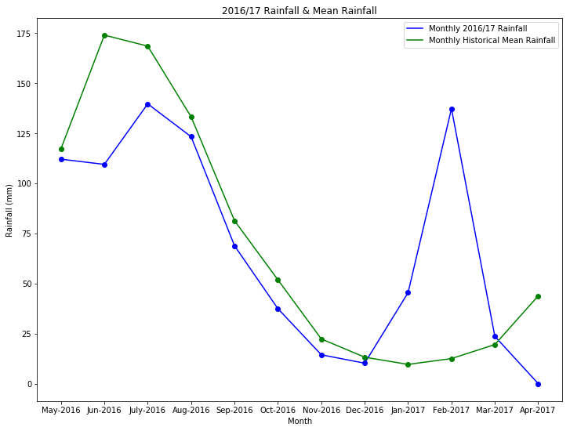

```python
month_rainfall = []
#month_evap = []
x = [1,2,3,4,5,6,7,8,9,10,11,12]
#zeros_12 = np.zeros(12)
my_ticks = ['May-2016', 'Jun-2016', 'July-2016', 'Aug-2016', 'Sep-2016', 'Oct-2016',
            'Nov-2016', 'Dec-2016', 'Jan-2017', 'Feb-2017', 'Mar-2017', 'Apr-2017']
avg_rainfall = [117.2,173.9,168.4,133.1,81.3,51.8,22.3,13.2,9.6,12.5,19.5,43.8]

for item in months:
    month_rainfall.append(weather[item]['Rainfall (mm)'].sum())

#for item in months:
#    month_evap.append(weather[item]['Evaporation (mm)'].sum())

month_rainfall = [ round(i, 2) for i in month_rainfall ]

#month_evap = [ round(i, 2) for i in month_evap ]

month_rainfall = np.asarray(month_rainfall)
#month_evap = np.asarray(month_evap)

y = month_rainfall #- month_evap

# Get current size
fig_size = plt.rcParams["figure.figsize"]

# Set figure width to 12 and height to 9
fig_size[0] = 12
fig_size[1] = 9
plt.rcParams["figure.figsize"] = fig_size

blue_line = mlines.Line2D([], [], color='blue', markersize=15, label='Monthly 2016/17 Rainfall')
green_line = mlines.Line2D([], [], color='green', markersize=15, label='Monthly Historical Mean Rainfall')
lines = [blue_line, green_line]
labels = [line.get_label() for line in lines]
plt.legend(lines, labels)

plt.xticks(x, my_ticks)
plt.plot(x, y, '-b', marker='o')
plt.plot(x, avg_rainfall, '-g', marker='o')
#plt.plot(x,zeros_12)
plt.title('2016/17 Rainfall & Mean Rainfall')
plt.xlabel('Month')
plt.ylabel("Rainfall (mm)")
plt.show()
```

### Wind Power

According to http://www.culturechange.org/wind.htm annual average wind speeds of 9mph are required for a small wind turbine, where as a utility scale wind power turbine might require 13mph. I'll pick in the middle of these two values and assume that in general 11mph (roughly 18km/h) winds would be enough to power your average wind turbine.

I think that given the exploration I've done with the different wind speeds and the time of the maximum wind speed occurance, wind power would be **quite suitable** for the Perth region. Although the majority of our 9am wind speeds are below 18km/h, there is still a decent chunk which are making in above that 18km/h mark. When we look at the 3pm wind speeds we can see that they are more consistenly around that 18km/h mark; the trend is quite similar to the 9am wind speeds however it's just a tiny bit faster on average. And then there are the maximum wind speeds which only dipe below 18km/h on a handful of occassions; indicating that nearly every single day we have *at least* some wind which will be able to spin a wind turbing.

This gives even more fuel to wind power being suitable for the Perth region because our 9am wind speeds are pretty close to turning the turbine and our 3pm wind speeds are turning it close to half the time. So if the wind in fact did start to pick up after these time slots we'd be spinning the turbine most ofthe day, and even a lot of the night!

### Max, 9am & 3pm Wind Speed

```python
wind_9am = [weather[item].iloc[:,[0,13]] for item in months]
year_wind_9am = pd.concat(wind_9am)
year_wind_9am = year_wind_9am.sort_values(by='Date',ascending=True)
```

```python
wind_3pm = [weather[item].iloc[:,[0,19]] for item in months]
year_wind_3pm = pd.concat(wind_3pm)
year_wind_3pm = year_wind_3pm.sort_values(by='Date',ascending=True)
```

```python
wind_max = [weather[item].iloc[:,[0,7]] for item in months]
year_wind_max = pd.concat(wind_max)
year_wind_max = year_wind_max.sort_values(by='Date',ascending=True)
```

Here I've plot all the previous wind speed data into one figure. From this plot we could conclude that as the day progresses from 9am the wind must start to pick up; as the 3pm wind speeds are consistently greater than the 9am speeds. Seeing as our maximums are so much greater than our 9am and 3pm speeds we could also infer that if the wind is increasing from 9am to 3pm, it could also be increasing even more past 3pm to meet the maximum wind speeds. This would make sense because it's rare to have a day with almost all 15km/h wind speeds and then just one random gust of 50km/h wind; it would usually slowly increase, reach the maximum, and then start to decrease again.

The **maximum** wind speed shows that throughout Winter there's a lot of variability, probably due to the frequency of storms driving up the wind speeds. However, as we ease into the Summer months we don't see these huge spikes but our maximum wind speeds are consistently between 30km/h - 50km/h range.

The **9am** wind speed average seems to be around the 8km/h mark during May 2016 - September 2016, with the occasional spike upwards or downwards. Then from September 2016 - March 2017 we see the speed trend upwards; closer to an average of about 12km/h. And finally in April 2017 it looks like the speed is trending downwards again.

The **3pm** wind speeds show an almost identical trend to the 9am wind speeds. However, almost all the speeds on average are *consistently* faster than the 9am wind speeds; suggesting that the wind must slowly be increasing throughout the course of the day.

```python
weather['201701'].columns
```

```
Index(['Date', 'Minimum temperature (°C)', 'Maximum temperature (°C)',
       'Rainfall (mm)', 'Evaporation (mm)', 'Sunshine (hours)',
       'Direction of maximum wind gust ', 'Speed of maximum wind gust (km/h)',
       'Time of maximum wind gust', '9am Temperature (°C)',
       '9am relative humidity (%)', '9am cloud amount (oktas)',
       '9am wind direction', '9am wind speed (km/h)', '9am MSL pressure (hPa)',
       '3pm Temperature (°C)', '3pm relative humidity (%)',
       '3pm cloud amount (oktas)', '3pm wind direction',
       '3pm wind speed (km/h)', '3pm MSL pressure (hPa)'],
      dtype='object')
```

```python
output_file("wind_all.html")
output_notebook()

# create a new plot with a datetime axis type
p = figure(plot_width=900, plot_height=600, x_axis_type="datetime", x_axis_label='Date',
           y_axis_label='Wind Speed (km/h)', title='Max, 9am & 3pm Wind Speed Observations May ' +
           '2016 - April 2017 (from Perth BOM Metro Station)')

p.line(year_wind_max['Date'], year_wind_max['Speed of maximum wind gust (km/h)'], color='#e41a1c', alpha=0.8,
      legend='Maximum')
p.line(year_wind_3pm['Date'], year_wind_3pm['3pm wind speed (km/h)'], color='#4daf4a', alpha=0.5,
      legend='3pm')
p.line(year_wind_9am['Date'], year_wind_9am['9am wind speed (km/h)'], color='#377eb8', alpha=0.5,
      legend='9am')

show(p)
```

[interactive chart not shown]

This indicates that the wind might pick up speed after 3pm, which isn't really shown in our data set (hinted at in the previous plot).

```python
max_wind_time = [weather[item].iloc[:,[0,8]] for item in months]
year_wind_time = pd.concat(max_wind_time)
year_wind_time = year_wind_time.sort_values(by='Date',ascending=True)
year_wind_time['Time of maximum wind gust'].str[0:2].value_counts().idxmax()
```

```
'16'
```

### Solar Power

According to https://www.solarchoice.net.au/residential/residential-solar-power the average Australian family would need a 2.25kWh solar system to cover most of their electrical needs completely. They estimate that this system would produce somewhere between 9kWh - 13kWh per day for the average Perth household (https://www.solarchoice.net.au/blog/wp-content/uploads/Average-Daily-Production-of-Renewable-Energy.jpg). This lines up with https://www.billrepublic.com/average-electricity-usage/ who estimate that per year the average Australian household in 2014 used 5817kWh of electricity; which turns out to equate to roughly 16kWh of energy used per day - not *too* far off the estimate for the average Perth household. I'm going to compare what these two websites are claiming against the data collected from the BOM, and some rough assumptions made around how cloud cover affects solar pannel efficiency.

According to https://www.solarpowerauthority.com/how-to-calculate-your-peak-sun-hours/ clouds covering the Sun reduce a solar pannel's efficiency by about 25% - 40%; meaning that they're producing about 60% - 75% of their normal electricity output during this cloudy weather.

Let's make some more assumptions; I'm going to say that during winter the Sun will be shining on our solar pannel for a possible 7 hours, and in summer it'll be more like 9 hours. Looking at the sunshine over time plot below we can see that during our least sunny days (autumn, winter/start of spring) we average around 5 hours of sunlight. However, during the more sunny days (end of spring, summer) we are almost consistently getting over 10 hours of direct sunlight.

Roughly looking at both of our cloud cover plots we can see that in about 65% of these least sunny days the majority of the sky is covered in clouds; the other 35% of these days we have roughly no clouds or around a quarter of the sky covered in clouds (still a decent amount for the Sun to hit our solar pannel). Looking at the more sunny days we can see that the proportions are sort of switched. On about 75% of these more sunny days there is roughly no cloud cover or one eighth of the sky covered (barely anything). And then on the other 25% of the sunny days it's still only about half of the sky covered in clouds; rarely is the *whole* sky covered in clouds during summer.

From all these assumptions I'll create the following equations:

```python
winter_cloud = (7 * 0.65)*(2.25*0.65) # time * expected solar output from pannel
winter_sun = (7 * 0.35)*(2.25)
avg_winter_day = winter_cloud + winter_sun

summer_cloud = (9 * 0.25)*(2.25*0.65)
summer_sun = (9 * 0.75)*(2.25)
avg_summer_day = summer_cloud + summer_sun

# assuming half the year follows winter conditions and half the year follows summer conditions
year_solar_total = (avg_summer_day*182) + (avg_winter_day*183)
print(year_solar_total)
```

```
5589.556875
```

```python
year_solar_total / 5817 # our estimate / 2014 average Australian household electricity usage
```

```
0.9609002707581228
```

So by making some assumptions of solar pannel efficiency, and by looking at our plots to estimate how much cloud cover and sunlight we might expect on any given winter or summer day; we have calculated that our solar pannel would produce 5590kWh of electricity every year. This is **96%** of the (2014) total average electricity usage for an Australian household. Meaning that, by these calculations, your average Perth resident would on only be paying for 4% of their total years worth of electricity bills if they have a solar pannel system installed.

This alone shows that **solar power is perfectly suitable for a Perth household!** And with solar cells becoming even more efficient at absorbing sunlight, and with the technology to store this energy constantly advancing - you'd be spending money on electricity you could be saving *if you don't install solar pannels!*

### Sunshine

```python
sunshine = [weather[item].iloc[:,[0,5]] for item in months]
year_sunshine = pd.concat(sunshine)
year_sunshine = year_sunshine.sort_values(by='Date',ascending=True)
```

```python
output_file("sunshine.html")
output_notebook()

# create a new plot with a datetime axis type
p = figure(plot_width=900, plot_height=600, x_axis_type="datetime", x_axis_label='Date',
           y_axis_label='Sunshine (hours)', title='Hours of Bright Sunshine (in the 24 hours '+
          'to midnight) May 2016 - April 2017 (from Perth Airport)')

p.line(year_sunshine['Date'], year_sunshine['Sunshine (hours)'], color='#f03b20', alpha=1)

show(p)
```

[interactive chart not shown]

### 9am Cloud Cover

```python
cloud_9am = [weather[item].iloc[:,[0,11]] for item in months]
year_cloud_9am = pd.concat(cloud_9am)
year_cloud_9am = year_cloud_9am.sort_values(by='Date',ascending=True)
```

```python
output_file("cloud_9am.html")
output_notebook()

# create a new plot with a datetime axis type
p = figure(plot_width=900, plot_height=600, x_axis_type="datetime", x_axis_label='Date',
           y_axis_label='Cloud Amount (oktas)', title='9am Cloud Amount '+
          'May 2016 - April 2017 (from Perth Airport)')

p.vbar(year_cloud_9am['Date'], width=0.9, bottom=0, top=year_cloud_9am['9am cloud amount (oktas)'],
       color='#636363', line_width=1.8, legend='Cloud Cover')
p.line(year_sunshine['Date'], year_sunshine['Sunshine (hours)']*0.5, color='#f03b20', alpha=0.7,
      legend='Sunshine*0.5')
#p.circle(year_cloud_9am['Date'], year_cloud_9am['9am cloud amount (oktas)'], color='#636363', size=5)

show(p)
```

[interactive chart not shown]

### 3pm Cloud Cover

```python
cloud_3pm = [weather[item].iloc[:,[0,17]] for item in months]
year_cloud_3pm = pd.concat(cloud_3pm)
year_cloud_3pm = year_cloud_3pm.sort_values(by='Date',ascending=True)
```

```python
output_file("cloud_3pm.html")
output_notebook()

# create a new plot with a datetime axis type
p = figure(plot_width=900, plot_height=600, x_axis_type="datetime", x_axis_label='Date',
           y_axis_label='Cloud Amount (oktas)', title='3pm Cloud Amount '+
          'May 2016 - April 2017 (from Perth Airport)')

p.vbar(year_cloud_3pm['Date'], width=0.9, bottom=0, top=year_cloud_3pm['3pm cloud amount (oktas)'],
       color='#636363', line_width=1.8, legend='Cloud Cover')
p.line(year_sunshine['Date'], year_sunshine['Sunshine (hours)']*0.5, color='#f03b20', alpha=0.7,
      legend='Sunshine*0.5')

show(p)
```

[interactive chart not shown]